# RNA-seq Analysis Project

## Gene Ontology (GO) Enrichment Analysis

I filtered for the NA padj genes and for padj < 0.1 and log2FoldChange > 1 or <-1

```r
DE <- DE[DE$padj < 0.1,] # selecting only the genes with adj pvalue lower than 0.1
DE <- DE[abs(DE$log2FoldChange) > 1,] # selecting genes that are over/under expressed
# absoolute value of log2 fold change higher than 1
summary(DE)
```

```
out of 5682 with nonzero total read count
adjusted p-value < 0.1
LFC > 0 (up)       : 2400, 42%
LFC < 0 (down)     : 3282, 58%
outliers [1]       : 0, 0%
low counts [2]     : 0, 0%
(mean count < 1)
[1] see 'cooksCutoff' argument of ?results
[2] see 'independentFiltering' argument of ?results
```

```r
# 5682 genes with log2 fold change higher than 1 or lower than -1 and pvalue lower than 0.1
```

## Gene Ontology (GO) Enrichment Analysis

Before the enrichment I added back the gene names to the results, to be able to perform the gene onthology analysis

```r
library("AnnotationDbi")
library("org.Hs.eg.db")

DE$symbol <- mapIds(org.Hs.eg.db, # becous the sample are form Humans
                    keys=rownames(DE),
                    column="SYMBOL",
                    keytype="ENSEMBL",
                    multiVals="first")
```

## Gene Ontology (GO) Enrichment Analysis

Analysis and plots

```r
library(clusterProfiler)
GO_BP <- enrichGO(DE$symbol, OrgDb = "org.Hs.eg.db",
                  keyType = "SYMBOL", ont = "BP")
GO_MF <- enrichGO(DE$symbol, OrgDb = "org.Hs.eg.db",
                  keyType = "SYMBOL", ont = "MF")
GO_CC <- enrichGO(DE$symbol, OrgDb = "org.Hs.eg.db",
                  keyType = "SYMBOL", ont = "CC")
```

## Gene Ontology (GO) Enrichment Analysis

*Choice one of the GO enrichment results and report how many categories are significant (p.adjust < 0.05)*

```r
GO_df <- as.data.frame(GO_BP) # save the GO analysis results as a data frame
summary(GO_df[GO_df$p.adjust < 0.05,])
```

```
      ID            Description         GeneRatio           BgRatio
 Length:939         Length:939         Length:939         Length:939
 Class :character   Class :character   Class :character   Class :character
 Mode  :character   Mode  :character   Mode  :character   Mode  :character



     pvalue             p.adjust             qvalue             geneID
 Min.   :0.000e+00   Min.   :0.0000000   Min.   :0.0000000   Length:939
 1st Qu.:6.042e-06   1st Qu.:0.0001572   1st Qu.:0.0001225   Class :character
 Median :3.752e-04   Median :0.0048804   Median :0.0038034   Mode  :character
 Mean   :1.547e-03   Mean   :0.0123216   Mean   :0.0096024
 3rd Qu.:2.342e-03   3rd Qu.:0.0203741   3rd Qu.:0.0158778
 Max.   :7.587e-03   Max.   :0.0496034   Max.   :0.0386566
     Count
 Min.   :  6.00
 1st Qu.: 14.00
 Median : 30.00
 Mean   : 40.03
 3rd Qu.: 55.00
 Max.   :191.00
```

```r
#  show the summary of the analysis - 939 categories with significant p value
```

## Gene Ontology (GO) Enrichment Analysis

*How many genes are present in the most enriched category of the GO enrichment result?* To answare the question I ordered the data frame by Gene Ratio

```r
GO_df <- GO_df[order(-GO_df$Count), ]
```

|  | Description | GeneRatio | p.adjust | Count |
| --- | --- | --- | --- | --- |
| GO:0007389 | pattern specification process | 191/3370 | 0 | 191 |
| GO:0048568 | embryonic organ development | 172/3370 | 0 | 172 |
| GO:0061564 | axon development | 166/3370 | 0 | 166 |
| GO:0003002 | regionalization | 155/3370 | 0 | 155 |
| GO:0007409 | axonogenesis | 153/3370 | 0 | 153 |
| GO:0051960 | regulation of nervous system development | 150/3370 | 0 | 150 |

## Gene Ontology (GO) Enrichment Analysis

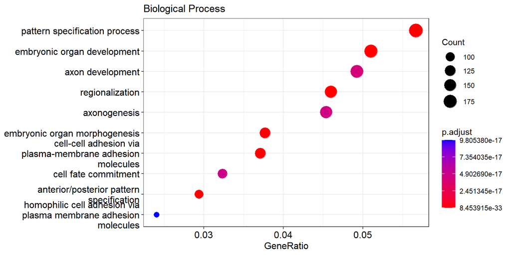

```r
dotplot(GO_BP, title = "Biological Process")
```

## Gene Ontology (GO) Enrichment Analysis

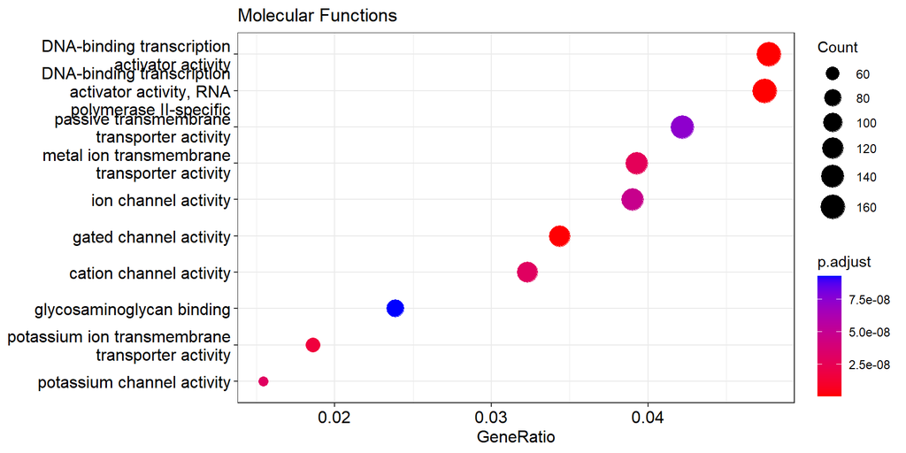

```r
dotplot(GO_MF, title = "Molecular Functions")
```

## Gene Ontology (GO) Enrichment Analysis

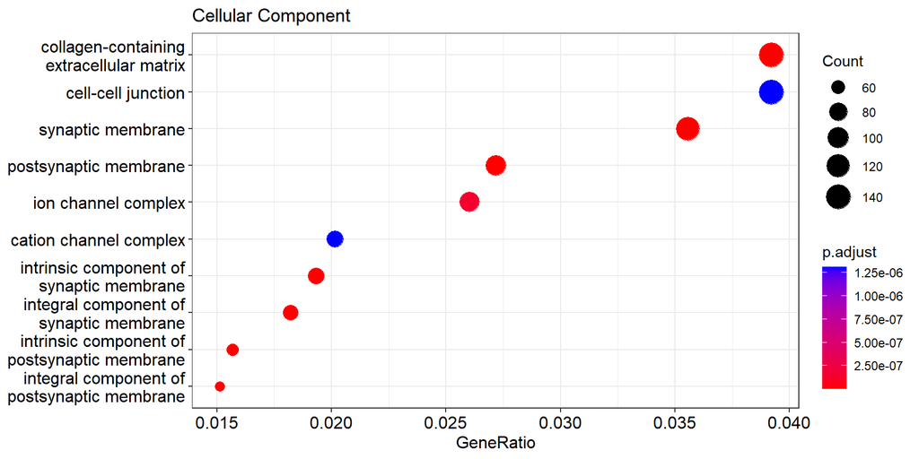

```r
dotplot(GO_CC, title = "Cellular Component")
```

## Gene Ontology (GO) Enrichment Analysis

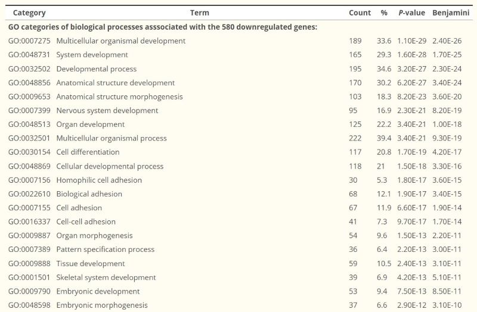

## More Plots

```r
EnhancedVolcano(DEresults,
                lab = DEresults$symbol,
                x = 'log2FoldChange',
                y = 'pvalue',
                title = 'Down syndrome versus Normal',
                pCutoff = 0.05,
                FCcutoff = 2,
                pointSize = 3.0,
                cutoffLineType = 'twodash',
                col = c('medium blue', 'steel blue', 'dodger blue', 'sky blue'),
                legendPosition = 'bottom',
                drawConnectors = TRUE,
                widthConnectors = 0.756,
                labSize = 5.0) + coord_flip()
```

## More Plots

[figure not shown]

```r
DEresults
```

```
log2 fold change (MLE): Factor.Value.disease. Down syndrome vs normal
Wald test p-value: Factor.Value.disease. Down syndrome vs normal
DataFrame with 38233 rows and 7 columns
                 baseMean log2FoldChange     lfcSE         stat       pvalue
                <numeric>      <numeric> <numeric>    <numeric>    <numeric>
ENSG00000164778  1035.547       -13.1602  1.651907     -7.96670  1.62970e-15
ENSG00000268658   417.426        12.4670  1.034309     12.05341  1.86085e-33
ENSG00000213973   312.505        12.0504  1.366170      8.82055  1.13903e-18
ENSG00000279377  2093.755        11.6779  0.647868     18.02518  1.23601e-72
ENSG00000179059  4570.377        11.5073  0.410577     28.02719 7.57798e-173
...                   ...            ...       ...          ...          ...
ENSG00000143727 3750.1305   -8.39023e-05  0.116126 -7.22509e-04     0.999424
ENSG00000232906   12.2703    7.69399e-05  0.494980  1.55440e-04     0.999876
ENSG00000131115  778.6499   -3.76280e-05  0.114039 -3.29957e-04     0.999737
ENSG00000215012  954.9119    1.54412e-05  0.130135  1.18655e-04     0.999905
ENSG00000177675   26.5819    1.09612e-05  0.450887  2.43104e-05     0.999981
                        padj       symbol
                   <numeric>  <character>
ENSG00000164778  7.01902e-14          EN2
ENSG00000268658  3.49582e-31    LINC00664
ENSG00000213973  7.17994e-17        ZNF99
ENSG00000279377  9.53898e-70           NA
ENSG00000179059 1.08195e-168        ZFP42
...                      ...          ...
ENSG00000143727     0.999845         ACP1
ENSG00000232906     0.999940 LOC100533634
ENSG00000131115     0.999916       ZNF227
ENSG00000215012     0.999940        RTL10
ENSG00000177675     0.999981      CD163L1
```

## More Plots

MA plot:

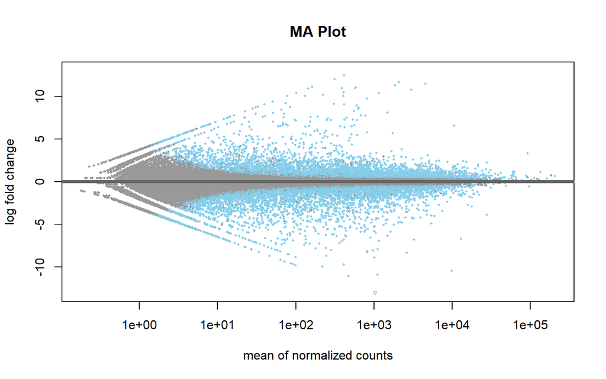

```r
plotMA(object = DEresults, ylim = c(-13, 13), main = 'MA Plot', colSig = "sky blue")
```